# Automatic vs Manual Transmissions

Matthew Thomas

2024-08-24

### Executive Summary:

In the past, vehicles with manual transmissions on average were more fuel-efficient than their automatic counterparts. However, as modern automatics have gained additional gears and relied less on a torque converter, the fuel economy gap has been closing. In fact, we analyzed the car data in the `mtcars` data set, and found the fuel economy, as measured by their mile-per-gallon (mpg), of manual-transmission cars now exceeds the mpg of the automatic-transmission cars.

### Exploratory Analysis:

**Dimensions of data set:**

```
## [1] 32 11
```

This car data set has 32 different cars, and 11 columns representing 10 features and a target value.

**Columns of the data set:**

```
##  [1] "mpg"  "cyl"  "disp" "hp"   "drat" "wt"   "qsec" "vs"   "am"   "gear"
## [11] "carb"
```

The feature of interest is `am`, which represents the type of transmission in the car. The target values is the `mpg`, miles-per-gallon.

**Class of features:**

```
##       mpg       cyl      disp        hp      drat        wt      qsec        vs
## "numeric" "numeric" "numeric" "numeric" "numeric" "numeric" "numeric" "numeric"
##        am      gear      carb
## "numeric" "numeric" "numeric"
```

The `mpg` is a continuous, numeric variable, as expected, but the `am` values also numeric. In our analysis, we treated it as a factor variable, so we changed its class.

**Summary of Transmission data:**

```
##  0  1
## 19 13
```

This confirms that the `am` values were converted to factors. The factor `0` indicates that the car has an automatic transmission, and a `1` indicates that it has a manual transmission.

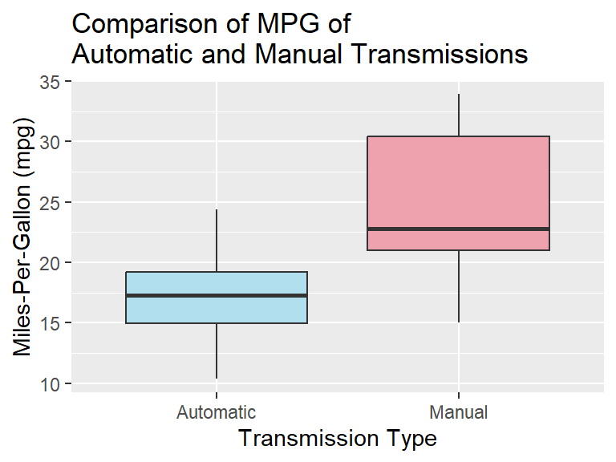

### Analysis:

To test our hypothesis that the automatic cars in our data set have lower fuel economy than the manual-transmission cars, we created a linear regression model. The `mpg` values were our target, and the `am` values were our regressor. We excluded a y-intercept to make the results easier to interpret.

**Linear model coefficients:**

```
##     Estimate Std. Error  t value     Pr(>|t|)
## am0 17.14737   1.124603 15.24749 1.133983e-15
## am1 24.39231   1.359578 17.94109 1.376283e-17
```

According to this model, the automatic transmission cars contribute just 17.15 to the mpg while the manual transmission cars contribute 24.39 to the mpg, a significant difference.

**Confidence intervals for coefficients:**

```
##        2.5 %   97.5 %
## am0 14.85062 19.44411
## am1 21.61568 27.16894
```

Although these coefficient are just estimates, we’re 95% sure that the actual contribution to mpg by the automatic-transmission cars lies between 14.9 and 19.4. And for the manual-transmission cars, the range of values is 21.6 to 27.2. Like in the box plot above, there’s a clear difference between the values for each type of transmission.

**R-squared value for model:**

```
## [1] 0.9486625
```

One metric for confirming the efficacy of the model is the $R^2$ value, which represents the proportion of total variation accounted for by the model. In this case, the model is able to account for 94.9% of the variance in the data.

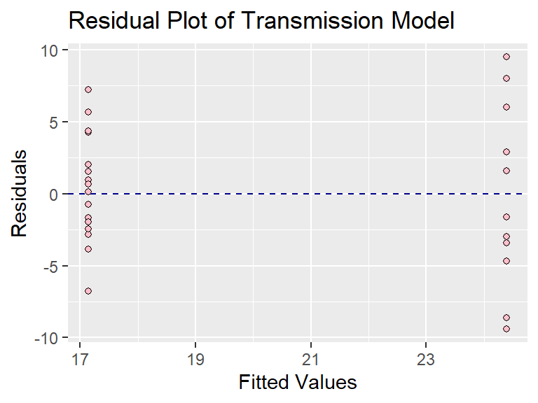

The residual plot indicates that the residuals are evenly and randomly distributed around the zero residual line, confirming that linear model is an appropriate method for describing the relationship between car transmissions and mpg.

**Mean of the residuals:**

```
## [1] -1.838807e-16
```

The zero mean of the residuals also confirms the visual proof in the residual plot, adding to the evidence that this linear model is sound.

**Test normality of standardized residuals:**

```
##
##  Shapiro-Wilk normality test
##
## data:  rstandard(mdl)
## W = 0.98284, p-value = 0.8767
```

And finally, we used the Shapiro-Wilk test to check the normalcy of the residuals. The p-value of 0.88 is well above the typical alpha value of 0.05, confirming the null hypothesis that the residuals have a normal distribution, an assumption of our linear model.